# 德国Ebay网站二手车数据分析

1、从不同维度分析近三十年的二手车数据

2、寻找与二手车价格有相关性的因素

3、通过线性回归预测二手车价格

4、通过聚类分析二手车类型。

```python
import numpy as np
import pandas as pd
import seaborn as sns
import matplotlib.pyplot as plt
from matplotlib import font_manager
from datetime import datetime
from sklearn.preprocessing import LabelEncoder
from scipy import stats
%pylab inline
%matplotlib inline
sns.set()
import warnings
warnings.filterwarnings('ignore')
from sklearn.cluster import KMeans #Kmeans
from sklearn.preprocessing import MinMaxScaler

import statsmodels.api as sm
```

```python
pd.set_option('display.max_columns', None)
```

```python
plt.rcParams['font.sans-serif'] = ['Microsoft YaHei']  # 用来正常显示中文标签
plt.rcParams['axes.unicode_minus'] = False
```

```python
row_data = pd.read_csv('autos.csv',header=0,encoding='latin-1')
```

```python
len(row_data)
```

```
371528
```

```python
row_data.head()
```

|  | dateCrawled | name | seller | offerType | price | abtest | vehicleType | yearOfRegistration | gearbox | powerPS | model | kilometer | monthOfRegistration | fuelType | brand | notRepairedDamage | dateCreated | nrOfPictures | postalCode | lastSeen |
| --- | --- | --- | --- | --- | --- | --- | --- | --- | --- | --- | --- | --- | --- | --- | --- | --- | --- | --- | --- | --- |
| 0 | 2016-03-24 11:52:17 | Golf_3_1.6 | privat | Angebot | 480 | test | NaN | 1993 | manuell | 0 | golf | 150000 | 0 | benzin | volkswagen | NaN | 2016-03-24 00:00:00 | 0 | 70435 | 2016-04-07 03:16:57 |
| 1 | 2016-03-24 10:58:45 | A5_Sportback_2.7_Tdi | privat | Angebot | 18300 | test | coupe | 2011 | manuell | 190 | NaN | 125000 | 5 | diesel | audi | ja | 2016-03-24 00:00:00 | 0 | 66954 | 2016-04-07 01:46:50 |
| 2 | 2016-03-14 12:52:21 | Jeep_Grand_Cherokee_"Overland" | privat | Angebot | 9800 | test | suv | 2004 | automatik | 163 | grand | 125000 | 8 | diesel | jeep | NaN | 2016-03-14 00:00:00 | 0 | 90480 | 2016-04-05 12:47:46 |
| 3 | 2016-03-17 16:54:04 | GOLF_4_1_4__3TÜRER | privat | Angebot | 1500 | test | kleinwagen | 2001 | manuell | 75 | golf | 150000 | 6 | benzin | volkswagen | nein | 2016-03-17 00:00:00 | 0 | 91074 | 2016-03-17 17:40:17 |
| 4 | 2016-03-31 17:25:20 | Skoda_Fabia_1.4_TDI_PD_Classic | privat | Angebot | 3600 | test | kleinwagen | 2008 | manuell | 69 | fabia | 90000 | 7 | diesel | skoda | nein | 2016-03-31 00:00:00 | 0 | 60437 | 2016-04-06 10:17:21 |

'dateCrawled':'广告登出时间','name':'汽车名称','seller':'销售方','offerType':'提供类型','price':'销售价','abtest':'ab检测','vehicleType':'汽车类型', 'yearOfRegistration':'注册年份','gearbox':'汽车变速箱','powerPS':'发动机功率','model':'模型','kilometer':'行驶公里','monthOfRegistration':'注册月份', 'fuelType':'燃料类型','brand':'汽车品牌','notRepairedDamage':'无修理损伤','dateCreated':'在ebay首次创建广告的时间','nrOfPictures':'图片数量','postalCode':'邮编', 'lastSeen':'最后一次浏览日期'

```python
row_data.shape
```

```
(371528, 20)
```

## 数据预处理

```python
#去重
row_data.drop_duplicates(inplace=True)
```

```python
row_data.shape
```

```
(371524, 20)
```

```python
row_data.dtypes
```

```
dateCrawled            object
name                   object
seller                 object
offerType              object
price                   int64
abtest                 object
vehicleType            object
yearOfRegistration      int64
gearbox                object
powerPS                 int64
model                  object
kilometer               int64
monthOfRegistration     int64
fuelType               object
brand                  object
notRepairedDamage      object
dateCreated            object
nrOfPictures            int64
postalCode              int64
lastSeen               object
dtype: object
```

```python
row_data.info()
```

```
<class 'pandas.core.frame.DataFrame'>
Int64Index: 371524 entries, 0 to 371527
Data columns (total 20 columns):
 #   Column               Non-Null Count   Dtype
---  ------               --------------   -----
 0   dateCrawled          371524 non-null  object
 1   name                 371524 non-null  object
 2   seller               371524 non-null  object
 3   offerType            371524 non-null  object
 4   price                371524 non-null  int64
 5   abtest               371524 non-null  object
 6   vehicleType          333655 non-null  object
 7   yearOfRegistration   371524 non-null  int64
 8   gearbox              351315 non-null  object
 9   powerPS              371524 non-null  int64
 10  model                351040 non-null  object
 11  kilometer            371524 non-null  int64
 12  monthOfRegistration  371524 non-null  int64
 13  fuelType             338138 non-null  object
 14  brand                371524 non-null  object
 15  notRepairedDamage    299464 non-null  object
 16  dateCreated          371524 non-null  object
 17  nrOfPictures         371524 non-null  int64
 18  postalCode           371524 non-null  int64
 19  lastSeen             371524 non-null  object
dtypes: int64(7), object(13)
memory usage: 59.5+ MB
```

```python
#检测缺失列
row_data.isnull().any()
```

```
dateCrawled            False
name                   False
seller                 False
offerType              False
price                  False
abtest                 False
vehicleType             True
yearOfRegistration     False
gearbox                 True
powerPS                False
model                   True
kilometer              False
monthOfRegistration    False
fuelType                True
brand                  False
notRepairedDamage       True
dateCreated            False
nrOfPictures           False
postalCode             False
lastSeen               False
dtype: bool
```

```python
#查看各类缺失值统计数量
row_data.isnull().sum()
```

```
dateCrawled                0
name                       0
seller                     0
offerType                  0
price                      0
abtest                     0
vehicleType            37869
yearOfRegistration         0
gearbox                20209
powerPS                    0
model                  20484
kilometer                  0
monthOfRegistration        0
fuelType               33386
brand                      0
notRepairedDamage      72060
dateCreated                0
nrOfPictures               0
postalCode                 0
lastSeen                   0
dtype: int64
```

```python
new_data = row_data.copy()
```

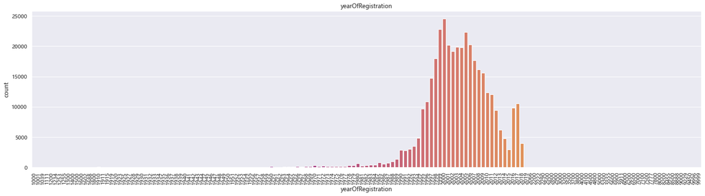

```python
sns.countplot(new_data['yearOfRegistration'], palette="plasma")
plt.xticks(rotation=90)
fig = plt.gcf()
fig.set_size_inches(25,6)
plt.title('yearOfRegistration')
plt.savefig('./image/所有数据注册年份.png')
plt.show()
```

在查看了所有数据后的注册年份柱状图之后，可以发现，在这列数据中是有一些异常值的存在，因为本次分析目的是为了分析近三十年的二手汽车市场的情况，所以我们只需要取1990-2020年这些的数据。

```python
#取近三十年数据。
data = new_data[new_data["yearOfRegistration"].between(1990, 2020, inclusive=True)]
```

```python
data.shape
```

```
(360799, 20)
```

```python
#缺失值处理
data["vehicleType"].fillna("Other", inplace=True)
data["gearbox"].fillna("Unspecified", inplace=True)
data["model"].fillna("Other",inplace=True)
data["notRepairedDamage"].fillna("other",inplace=True)
data["vehicleType"].fillna("Other", inplace=True)
```

```python
data.dtypes
```

```
dateCrawled            object
name                   object
seller                 object
offerType              object
price                   int64
abtest                 object
vehicleType            object
yearOfRegistration      int64
gearbox                object
powerPS                 int64
model                  object
kilometer               int64
monthOfRegistration     int64
fuelType               object
brand                  object
notRepairedDamage      object
dateCreated            object
nrOfPictures            int64
postalCode              int64
lastSeen               object
dtype: object
```

```python
#由于数据集是德语的，所以需要将一些德语单词转换成英语
data["offerType"] = data["offerType"].map({'Gesuch':"Request",'Angebot':'Offer'})

data["fuelType"] = data["fuelType"].map({'benzin':'Gasoline','diesel':'Diesel','other':'Other','lpg':'Lpg','hybrid':'Hybrid','cng':'Cng','elektro':'Electric'})

data["notRepairedDamage"] = data["notRepairedDamage"].map({'other':'Other','ja':'Yes','nein':'No'})
```

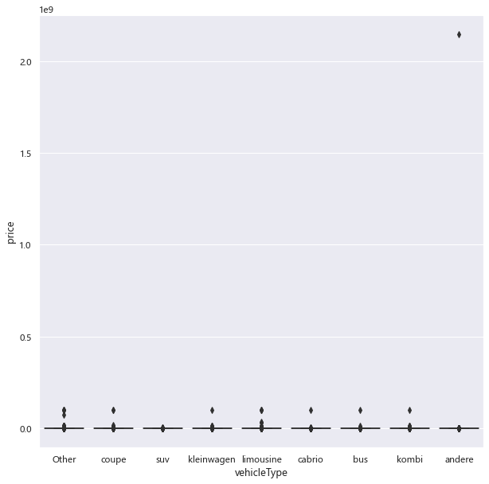

```python
#异常值检测
plt.figure(figsize=(10,10))
sns.boxplot(data=data, x='vehicleType', y='price', palette='plasma')
plt.savefig('./image/vehicleType-price-boxplot.png')
plt.show()
```

从上图可以看到汽车类型与销售价格存在异常值，所以应该根据实际情况去按照一定条件去筛选数据。

```python
# 所有车型价格的平均值
data_median = data.groupby("vehicleType")["price"].median()

# 占所有车型价格的百分之75
data_quantile75 = data.groupby("vehicleType")["price"].quantile(0.75)

#占所有车型价格的25%
data_quantile25 = data.groupby("vehicleType")["price"].quantile(0.25)

# 计算每一种车型的价格，
IQR = (data_quantile75 - data_quantile25)*1.5 + data_median
IQR
```

```
vehicleType
Other          5026.5
andere         7900.0
bus           13932.0
cabrio        20951.5
coupe         23749.0
kleinwagen     5760.0
kombi         13200.0
limousine     13001.5
suv           29100.0
Name: price, dtype: float64
```

在这里我们用四分位距来筛选出异常值

```python
#删掉异常值
data = data[((data["vehicleType"] == "andere") & (data["price"] <= 8429)) |
        ((data["vehicleType"] == "Other") & (data["price"] <= 3708)) |
        ((data["vehicleType"] == "suv") & (data["price"] <= 28800)) |
        ((data["vehicleType"] == "kombi") & (data["price"] <= 13076)) |
        ((data["vehicleType"] == "bus") & (data["price"] <= 13948)) |
        ((data["vehicleType"] == "cabrio") & (data["price"] <= 21400)) |
        ((data["vehicleType"] == "limousine") & (data["price"] <= 12801)) |
        ((data["vehicleType"] == "coupe") & (data["price"] <= 24300)) |
        ((data["vehicleType"] == "kleinwagen") & (data["price"] <= 5775))]
```

```python
data.shape
```

```
(315188, 20)
```

```python
#把广告登出时间和广告制作时间的年月拆开
data["yearOfCreation"] = data['dateCreated'].apply(lambda x: datetime.datetime.strptime(x,'%Y-%m-%d %H:%M:%S').date().strftime('%Y'))
data["monthOfCreation"] = data['dateCreated'].apply(lambda x: datetime.datetime.strptime(x,'%Y-%m-%d %H:%M:%S').date().strftime('%B'))
data["yearCrawled"] = data['dateCrawled'].apply(lambda x: datetime.datetime.strptime(x,'%Y-%m-%d %H:%M:%S').date().strftime('%Y'))
data["monthCrawled"] = data['dateCrawled'].apply(lambda x: datetime.datetime.strptime(x,'%Y-%m-%d %H:%M:%S').date().strftime('%B'))
```

```python
#构建新特征，最后一次浏览时间-创建广告的时间 = 广告在线天数
from_time = data['dateCreated'].apply(lambda x: datetime.datetime.strptime(x,'%Y-%m-%d %H:%M:%S').date())
to_time = data['lastSeen'].apply(lambda x: datetime.datetime.strptime(x,'%Y-%m-%d %H:%M:%S').date())
no_days = abs((to_time-from_time))
data["Ad_online_days"]= (no_days / np.timedelta64(1, 'D')).astype(int)
```

```python
data.head()
```

|  | dateCrawled | name | seller | offerType | price | abtest | vehicleType | yearOfRegistration | gearbox | powerPS | model | kilometer | monthOfRegistration | fuelType | brand | notRepairedDamage | dateCreated | nrOfPictures | postalCode | lastSeen | yearOfCreation | monthOfCreation | yearCrawled | monthCrawled | Ad_online_days |
| --- | --- | --- | --- | --- | --- | --- | --- | --- | --- | --- | --- | --- | --- | --- | --- | --- | --- | --- | --- | --- | --- | --- | --- | --- | --- |
| 0 | 2016-03-24 11:52:17 | Golf_3_1.6 | privat | Offer | 480 | test | Other | 1993 | manuell | 0 | golf | 150000 | 0 | Gasoline | volkswagen | Other | 2016-03-24 00:00:00 | 0 | 70435 | 2016-04-07 03:16:57 | 2016 | March | 2016 | March | 14 |
| 1 | 2016-03-24 10:58:45 | A5_Sportback_2.7_Tdi | privat | Offer | 18300 | test | coupe | 2011 | manuell | 190 | Other | 125000 | 5 | Diesel | audi | Yes | 2016-03-24 00:00:00 | 0 | 66954 | 2016-04-07 01:46:50 | 2016 | March | 2016 | March | 14 |
| 2 | 2016-03-14 12:52:21 | Jeep_Grand_Cherokee_"Overland" | privat | Offer | 9800 | test | suv | 2004 | automatik | 163 | grand | 125000 | 8 | Diesel | jeep | Other | 2016-03-14 00:00:00 | 0 | 90480 | 2016-04-05 12:47:46 | 2016 | March | 2016 | March | 22 |
| 3 | 2016-03-17 16:54:04 | GOLF_4_1_4__3TÜRER | privat | Offer | 1500 | test | kleinwagen | 2001 | manuell | 75 | golf | 150000 | 6 | Gasoline | volkswagen | No | 2016-03-17 00:00:00 | 0 | 91074 | 2016-03-17 17:40:17 | 2016 | March | 2016 | March | 0 |
| 4 | 2016-03-31 17:25:20 | Skoda_Fabia_1.4_TDI_PD_Classic | privat | Offer | 3600 | test | kleinwagen | 2008 | manuell | 69 | fabia | 90000 | 7 | Diesel | skoda | No | 2016-03-31 00:00:00 | 0 | 60437 | 2016-04-06 10:17:21 | 2016 | March | 2016 | March | 6 |

```python
#注册月份映射关系改变一下
data["monthOfRegistration"].replace([0,12],[1,11],inplace=True)
```

```python
#构建新特征，车龄
data["yearsOld"] = 2020 - data["yearOfRegistration"]
```

```python
months = ["Jan","Feb","Mar","Apr","May","Jun","Jul","Aug","Sep","Oct","Nov"]
data["monthOfRegistration"].replace([i for i in range(1,12)],months,inplace=True)
```

```python
data.head()
```

|  | dateCrawled | name | seller | offerType | price | abtest | vehicleType | yearOfRegistration | gearbox | powerPS | model | kilometer | monthOfRegistration | fuelType | brand | notRepairedDamage | dateCreated | nrOfPictures | postalCode | lastSeen | yearOfCreation | monthOfCreation | yearCrawled | monthCrawled | Ad_online_days | yearsOld |
| --- | --- | --- | --- | --- | --- | --- | --- | --- | --- | --- | --- | --- | --- | --- | --- | --- | --- | --- | --- | --- | --- | --- | --- | --- | --- | --- |
| 0 | 2016-03-24 11:52:17 | Golf_3_1.6 | privat | Offer | 480 | test | Other | 1993 | manuell | 0 | golf | 150000 | Jan | Gasoline | volkswagen | Other | 2016-03-24 00:00:00 | 0 | 70435 | 2016-04-07 03:16:57 | 2016 | March | 2016 | March | 14 | 27 |
| 1 | 2016-03-24 10:58:45 | A5_Sportback_2.7_Tdi | privat | Offer | 18300 | test | coupe | 2011 | manuell | 190 | Other | 125000 | May | Diesel | audi | Yes | 2016-03-24 00:00:00 | 0 | 66954 | 2016-04-07 01:46:50 | 2016 | March | 2016 | March | 14 | 9 |
| 2 | 2016-03-14 12:52:21 | Jeep_Grand_Cherokee_"Overland" | privat | Offer | 9800 | test | suv | 2004 | automatik | 163 | grand | 125000 | Aug | Diesel | jeep | Other | 2016-03-14 00:00:00 | 0 | 90480 | 2016-04-05 12:47:46 | 2016 | March | 2016 | March | 22 | 16 |
| 3 | 2016-03-17 16:54:04 | GOLF_4_1_4__3TÜRER | privat | Offer | 1500 | test | kleinwagen | 2001 | manuell | 75 | golf | 150000 | Jun | Gasoline | volkswagen | No | 2016-03-17 00:00:00 | 0 | 91074 | 2016-03-17 17:40:17 | 2016 | March | 2016 | March | 0 | 19 |
| 4 | 2016-03-31 17:25:20 | Skoda_Fabia_1.4_TDI_PD_Classic | privat | Offer | 3600 | test | kleinwagen | 2008 | manuell | 69 | fabia | 90000 | Jul | Diesel | skoda | No | 2016-03-31 00:00:00 | 0 | 60437 | 2016-04-06 10:17:21 | 2016 | March | 2016 | March | 6 | 12 |

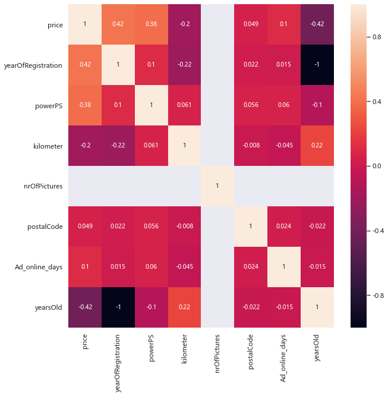

```python
corr= data.corr(method='kendall')
plt.figure(figsize=(10,10))
sns.heatmap(corr,annot=True)
plt.savefig('./image/kendall_corr.png')
plt.show()
```

通过上图可以看到，价格与注册年份相关性最大

## 数据探索

### 车辆类型分布

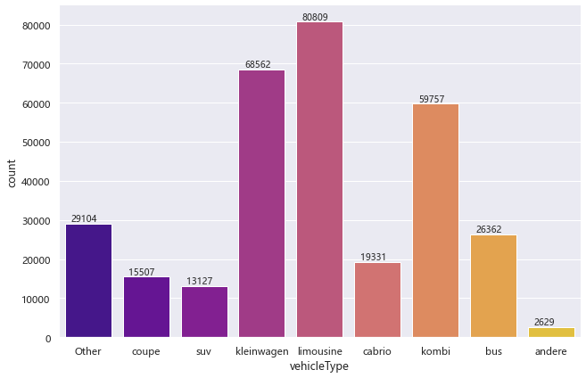

```python
vehicleType = sns.factorplot(x="vehicleType", data=data, kind="count",
                   palette="plasma", size=6, aspect=1.5)
for p in vehicleType.ax.patches:
    vehicleType.ax.annotate((p.get_height()), (p.get_x()+0.1, p.get_height()+500))
plt.savefig('./image/Total count of vehicles by type available on ebay for sale.png')
plt.show()
```

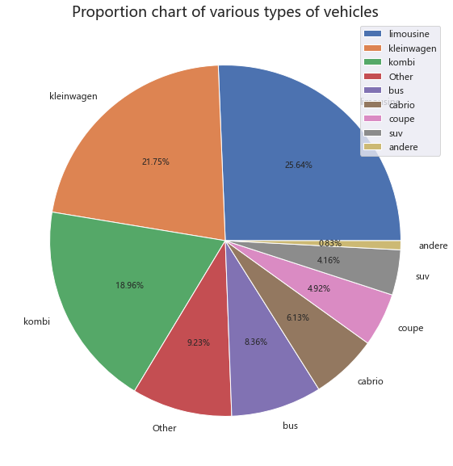

```python
plt.figure(figsize=(10,10))
plt.title('Proportion chart of various types of vehicles',fontdict={'fontsize':18})
plt.pie(data['vehicleType']. value_counts(),labels=data['vehicleType'].value_counts().index,autopct='%.2f%%',shadow=False)
plt.legend(loc='best',shadow=False,fontsize=11)
plt.savefig('./image/Proportion chart of various types of vehicles.png')
```

可以看到，在二手市场中豪华轿车limousine车最多，占比25%，其次为kleinwagen、kombi

### 变速箱分布

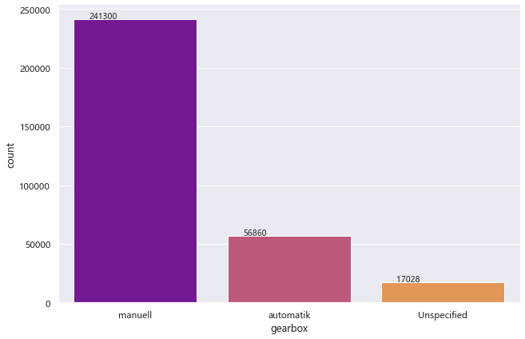

```python
gearbox = sns.factorplot(x="gearbox", data=data, kind="count",
                   palette="plasma", size=6, aspect=1.5)
for p in gearbox.ax.patches:
    gearbox.ax.annotate((p.get_height()), (p.get_x()+0.1, p.get_height()+500))
plt.savefig('./image/Transmission distribution diagram of vehicle class.png')
plt.show()
```

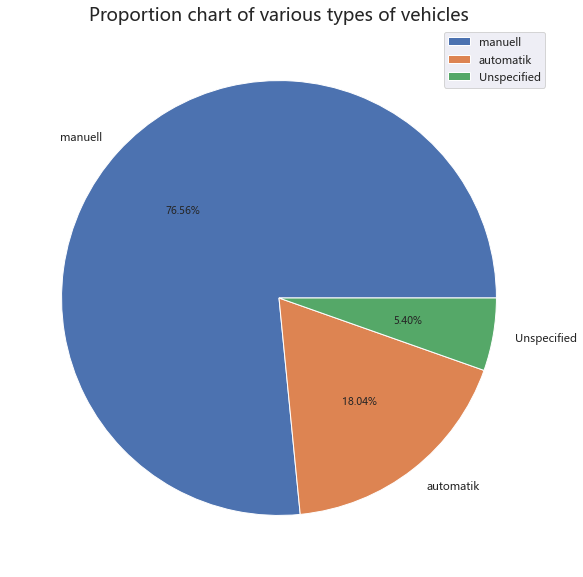

```python
plt.figure(figsize=(10,10))
plt.title('Proportion chart of various types of vehicles',fontdict={'fontsize':18})
plt.pie(data['gearbox']. value_counts(),labels=data['gearbox'].value_counts().index,autopct='%.2f%%',shadow=False)
plt.legend(loc='best',shadow=False,fontsize=11)
plt.savefig('./image/Proportion chart of gearbox of vehicles.png')
```

从上两图可以看到 ，在二手车市场大多数车都是手动挡，手动挡车辆数量是自动挡的4倍，占比高达76%

### 燃料类型分布

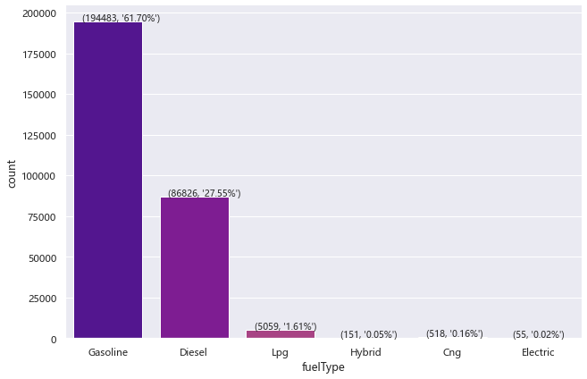

```python
fuelType = sns.factorplot(x="fuelType", data=data, kind="count",
                   palette="plasma", size=6, aspect=1.5)
for p in fuelType.ax.patches:
    fuelType.ax.annotate((p.get_height(),'{:.2f}%'.format(round(p.get_height()/len(data),4)*100)), (p.get_x()+0.1, p.get_height()+500))
plt.savefig('./image/Fuel type vehicle distribution.png')
plt.show()
```

大多数车所用的燃料都为汽油petrol，占比近62%，其次柴油

### 品牌分布

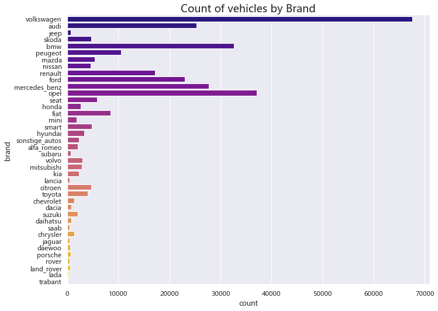

```python
brand = sns.factorplot(y="brand", data=data, kind="count",
                   palette="plasma", size=7, aspect=1.5)
brand.ax.set_title("Count of vehicles by Brand",fontdict={'size':18})
plt.savefig('./image/Count of vehicles by Brand.png')
plt.show()
```

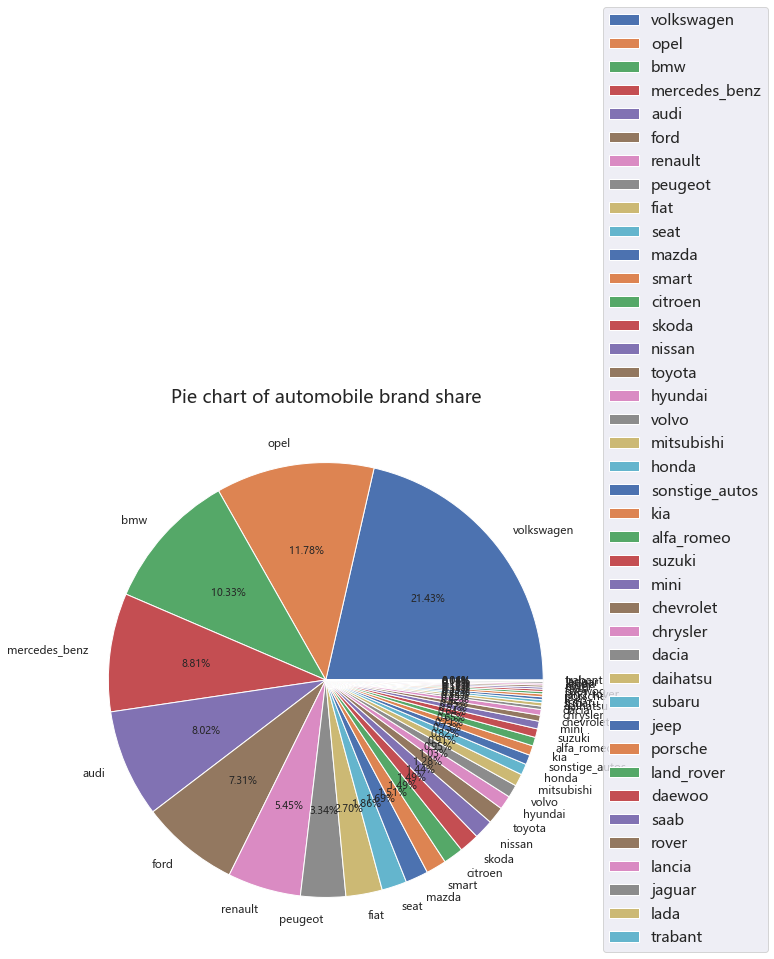

```python
plt.figure(figsize=(10,10))
plt.title('Pie chart of automobile brand share',fontdict={'fontsize':18})
plt.pie(data['brand']. value_counts(),labels=data['brand'].value_counts().index,autopct='%.2f%%',shadow=False)
plt.legend(bbox_to_anchor=(1.01, 0), loc=3, borderaxespad=0, fontsize=15)
plt.savefig('./image/Pie chart of automobile brand share.png')
```

从上图可以看到，品牌较多，二手车网站上大多数车都为大众汽车volkswagen，另外opel和bwn也是二手车交易市场上活跃的品牌

### 车龄

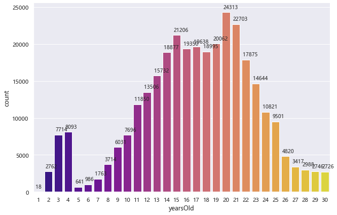

```python
yearsOld = sns.factorplot(x="yearsOld", data=data, kind="count",
                   palette="plasma", size=6, aspect=1.5)
for p in yearsOld.ax.patches:
    yearsOld.ax.annotate((p.get_height()), (p.get_x()+0.1, p.get_height()+500))
plt.savefig('./image/yearsOld.png')
plt.show()
```

这里可以看到，大部分二手车的使用年限都在10以上 。

### 行驶公里

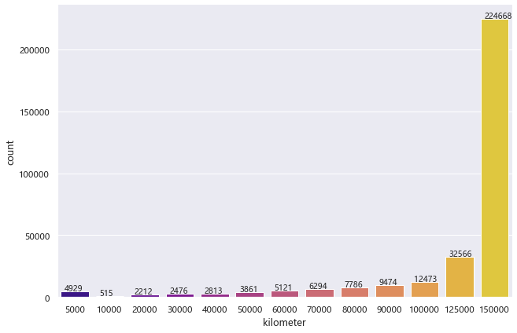

```python
Kilometer = sns.factorplot(x="kilometer", data=data, kind="count",
                   palette="plasma", size=6, aspect=1.5)
for p in Kilometer.ax.patches:
    Kilometer.ax.annotate((p.get_height()), (p.get_x()+0.1, p.get_height()+500))
plt.savefig('./image/Kilometer.png')
plt.show()
```

```python
print("行驶公里大于120000的车辆占总数的{:.2f}%".format(len(data[data['kilometer'] >120000])/len(data)*100))
```

```
行驶公里大于120000的车辆占总数的81.61%
```

从上图可以看到，绝大部分二手车行驶公里都已经超过12万公里，占总数的81%。

### 销售日期

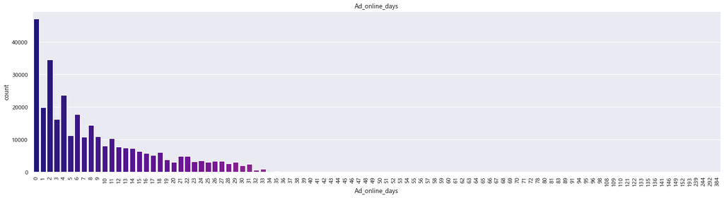

```python
sns.countplot(data['Ad_online_days'], palette="plasma")
plt.xticks(rotation=90)
fig = plt.gcf()
fig.set_size_inches(25,6)
plt.title('Ad_online_days')
plt.savefig('./image/Online sales days.png')
plt.show()
```

从上图可以看到，德国二手车销售市场需求量很大，大部分二手车能在10内卖出去，更多的车销售周期不会超过一个月。

### 注册年份

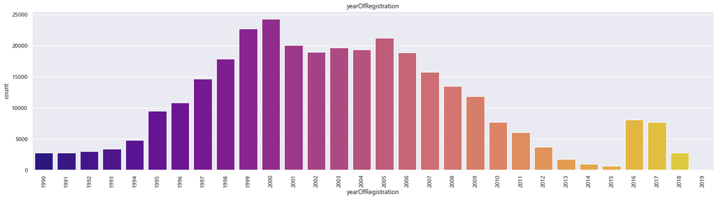

```python
sns.countplot(data['yearOfRegistration'], palette="plasma")
plt.xticks(rotation=90)
fig = plt.gcf()
fig.set_size_inches(25,6)
plt.title('yearOfRegistration')
plt.savefig('./image/近三十年汽车注册年份数据柱状图.png')
plt.show()
```

可以看到我们从数据中筛选了1990-2020间的数据，二手车大多数都是在1995-2010这段时间注册的，车龄较久。

### 注册年份&燃料类型

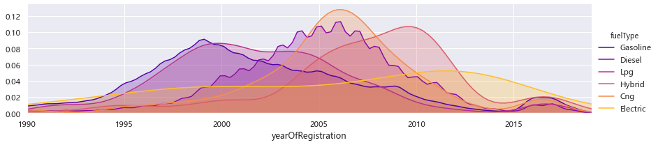

```python
fig = sns.FacetGrid(data,hue='fuelType',aspect=4,palette="plasma")
fig.map(sns.kdeplot,'yearOfRegistration',shade=True)

fig.set(xlim=(data['yearOfRegistration'].min(),data['yearOfRegistration'].max()))
plt.savefig('./image/注册年份&燃料类型.png')
fig.add_legend()
```

### 注册年份&变速箱

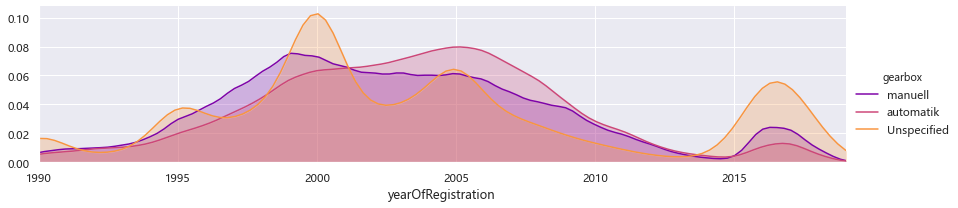

```python
fig = sns.FacetGrid(data,hue='gearbox',aspect=4,palette="plasma")
fig.map(sns.kdeplot,'yearOfRegistration',shade=True)

fig.set(xlim=(data['yearOfRegistration'].min(),data['yearOfRegistration'].max()))
plt.savefig('./image/注册年份&变速箱.png')
fig.add_legend()
```

可以看到，市场的需求是在不断变化的。随着时间的变化，二手市场自动挡的汽车在慢慢的增多。但是在15年后有一次转变。

### 价格

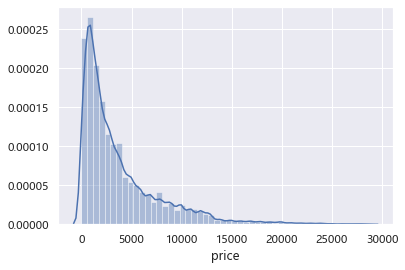

```python
sns.distplot(data.price)
plt.savefig('./image/Price.png')
```

```python
print("价格低于10000的车辆占总数的{:.2f}%".format(len(data[data['price'] <=10000])/len(data)*100))
```

```
价格低于10000的车辆占总数的91.73%
```

可以看到绝大部分价格都在10000以下,价格低于10000的车辆占总数的91.73%

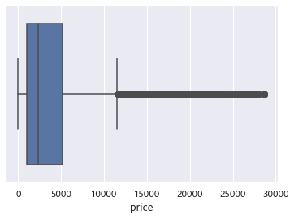

```python
sns.boxplot(data.price)
```

```python
print("价格低于5000的车占总数的{:.2f}%".format(len(data[data['price'] <5000])/len(data)*100))
```

```
价格低于5000的车占总数的74.31%
```

从以上图可以看到，德国二手车市场绝大部分车价格低于5000 ,价格低于5000的车占总数的74.31%

### 车辆类型&价格

```python
data.groupby('vehicleType')['price'].describe()
```

| vehicleType | count | mean | std | min | 25% | 50% | 75% | max |
| --- | --- | --- | --- | --- | --- | --- | --- | --- |
| Other | 29104.0 | 1088.442551 | 972.412561 | 0.0 | 300.0 | 849.0 | 1650.0 | 3700.0 |
| andere | 2629.0 | 2392.991251 | 2049.873565 | 0.0 | 750.0 | 1800.0 | 3600.0 | 8350.0 |
| bus | 26362.0 | 4675.304605 | 3343.967248 | 0.0 | 1999.0 | 3900.0 | 6750.0 | 13900.0 |
| cabrio | 19331.0 | 6895.899281 | 5229.713605 | 0.0 | 2790.0 | 5500.0 | 9980.0 | 21400.0 |
| coupe | 15507.0 | 6665.472690 | 6415.014524 | 0.0 | 1550.0 | 4000.0 | 10800.0 | 24299.0 |
| kleinwagen | 68562.0 | 1730.075727 | 1411.790772 | 0.0 | 650.0 | 1290.0 | 2500.0 | 5765.0 |
| kombi | 59757.0 | 3971.037435 | 3368.196925 | 0.0 | 1250.0 | 2850.0 | 6000.0 | 13049.0 |
| limousine | 80809.0 | 3758.224987 | 3208.826327 | 0.0 | 1200.0 | 2670.0 | 5700.0 | 12800.0 |
| suv | 13127.0 | 10878.461263 | 7105.094201 | 0.0 | 4950.0 | 9900.0 | 15800.0 | 28800.0 |

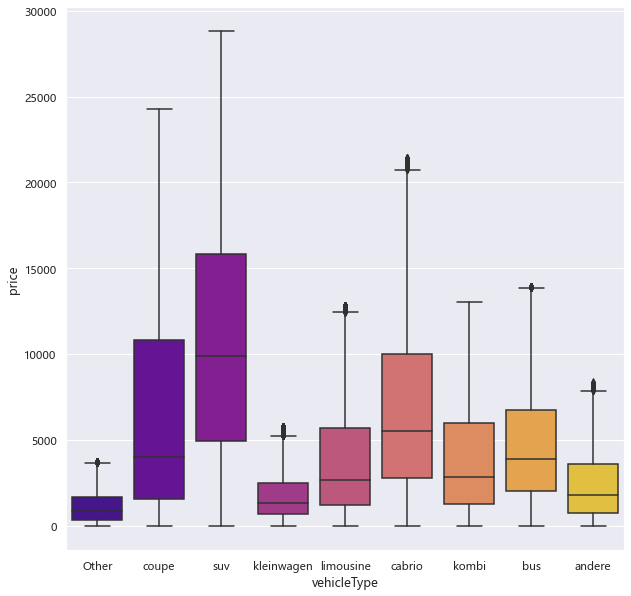

```python
plt.figure(figsize=(10,10))
sns.boxplot(data=data, x='vehicleType', y='price', palette='plasma')
plt.savefig('./image/Variation of the price range by the vehicle type.png')
plt.show()
```

从上图可以看到，各个汽车类型的都有一个稳定的价格区间。

1、价格最高的是SUV，价格稳定在4950-15800之间。

2、最低是Other部分，价位在300-1650之间

### 变速箱&价格

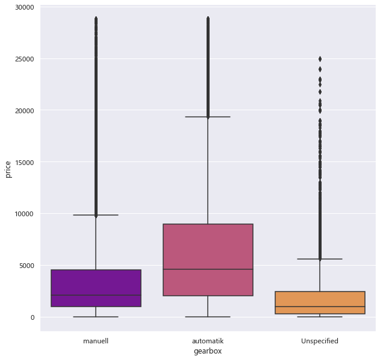

```python
plt.figure(figsize=(10,10))
sns.boxplot(data=data, x='gearbox', y='price', palette='plasma')
plt.savefig('./image/Variation of the price range by the gearbox.png')
plt.show()
```

从上图可以看到，二手车市场上自动挡车价格高于手动挡，虽然手动档车数量大于自动挡，但是手动挡车保值性较差

### 燃料类型&价格

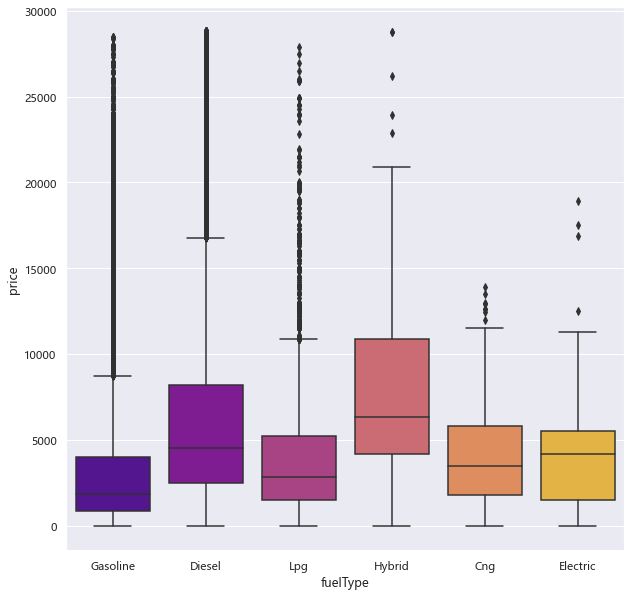

```python
plt.figure(figsize=(10,10))
sns.boxplot(data=data, x='fuelType', y='price', palette='plasma')
plt.savefig('./image/fuelType_price_boxplot.png')
plt.show()
```

从上图来看，混动车和柴油车价格整体价格要普遍高于其它燃料类型的车。

### 价格&品牌&车型

```python
trial = pd.DataFrame()
for b in list(data["brand"].unique()):
    for v in list(data["vehicleType"].unique()):
        z = data[(data["brand"] == b) & (data["vehicleType"] == v)]["price"].mean()
        trial = trial.append(pd.DataFrame({'brand':b , 'vehicleType':v , 'avgPrice':z}, index=[0]))#存入品牌B和汽车类型v的均价
trial = trial.reset_index()
del trial["index"]
trial["avgPrice"].fillna(0,inplace=True)
trial["avgPrice"].isnull().value_counts()
trial["avgPrice"] = trial["avgPrice"].astype(int)
trial.head(5)
```

|  | brand | vehicleType | avgPrice |
| --- | --- | --- | --- |
| 0 | volkswagen | Other | 1110 |
| 1 | volkswagen | coupe | 8355 |
| 2 | volkswagen | suv | 14105 |
| 3 | volkswagen | kleinwagen | 1628 |
| 4 | volkswagen | limousine | 3762 |

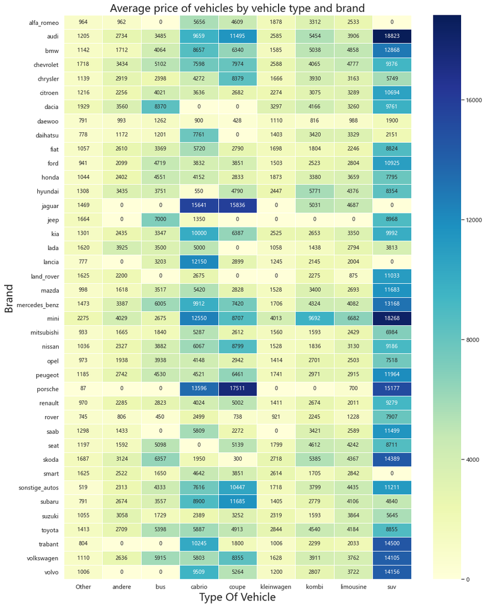

```python
tri = trial.pivot("brand","vehicleType", "avgPrice")
fig, ax = plt.subplots(figsize=(15,20))
sns.heatmap(tri,linewidths=1,cmap="YlGnBu",annot=True, ax=ax, fmt="d")
ax.set_title("Average price of vehicles by vehicle type and brand",fontdict={'size':20})
ax.xaxis.set_label_text("Type Of Vehicle",fontdict= {'size':20})
ax.yaxis.set_label_text("Brand",fontdict= {'size':20})
plt.savefig('./image/Average price of vehicles by vehicle type and brand.png')
plt.show()
```

## 多元线性回归

```python
#多元
y = data['price']
x = data[['kilometer', 'powerPS', 'yearsOld', 'Ad_online_days','yearOfRegistration']]
```

```python
model = sm.formula.ols('price ~ kilometer + powerPS + yearsOld + Ad_online_days + yearOfRegistration',data=data).fit()
y_pred = model.predict(x)
print('模型偏回归系数分别是：{}'.format(model.params))
```

```
模型偏回归系数分别是：Intercept              -0.120931
kilometer              -0.022711
powerPS                 3.432200
yearsOld             -249.356417
Ad_online_days         58.891084
yearOfRegistration      5.076164
dtype: float64
```

```python
data['price_pred'] = y_pred
```

```python
pd.DataFrame({'真实价格':data['price'],'预测价格':data['price_pred']})
```

|  | 真实价格 | 预测价格 |
| --- | --- | --- |
| 0 | 480 | 801.866335 |
| 1 | 18300 | 6601.547484 |
| 2 | 9800 | 5198.978695 |
| 3 | 1500 | 2270.266783 |
| 4 | 3600 | 5746.712338 |
| ... | ... | ... |
| 371522 | 0 | 3030.582136 |
| 371523 | 2200 | 7337.516119 |
| 371524 | 1199 | 3026.194638 |
| 371525 | 9200 | 2209.703868 |
| 371526 | 3400 | 2846.068694 |

315188 rows × 2 columns

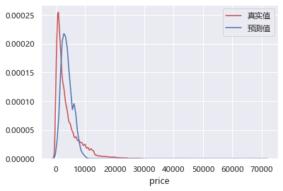

```python
ax1 = sns.distplot(y, hist=False, color="r", label="真实值")
sns.distplot(y_pred, hist=False, color="b", label="预测值" , ax=ax1)
plt.savefig('./image/真实值_预测值.png')
```

```python
 #验数据是否符正态分布
stats.shapiro(x)
```

```
(0.5065006017684937, 0.0)
```

利用shapiro函数可以计算得到P值，P值是小于0.05，也说明数据不服从正态分布

## 聚类分析

```python
data.head()
```

|  | dateCrawled | name | seller | offerType | price | abtest | vehicleType | yearOfRegistration | gearbox | powerPS | model | kilometer | monthOfRegistration | fuelType | brand | notRepairedDamage | dateCreated | nrOfPictures | postalCode | lastSeen | yearOfCreation | monthOfCreation | yearCrawled | monthCrawled | Ad_online_days | yearsOld | price_pred |
| --- | --- | --- | --- | --- | --- | --- | --- | --- | --- | --- | --- | --- | --- | --- | --- | --- | --- | --- | --- | --- | --- | --- | --- | --- | --- | --- | --- |
| 0 | 2016-03-24 11:52:17 | Golf_3_1.6 | privat | Offer | 480 | test | Other | 1993 | manuell | 0 | golf | 150000 | Jan | Gasoline | volkswagen | Other | 2016-03-24 00:00:00 | 0 | 70435 | 2016-04-07 03:16:57 | 2016 | March | 2016 | March | 14 | 27 | 801.866335 |
| 1 | 2016-03-24 10:58:45 | A5_Sportback_2.7_Tdi | privat | Offer | 18300 | test | coupe | 2011 | manuell | 190 | Other | 125000 | May | Diesel | audi | Yes | 2016-03-24 00:00:00 | 0 | 66954 | 2016-04-07 01:46:50 | 2016 | March | 2016 | March | 14 | 9 | 6601.547484 |
| 2 | 2016-03-14 12:52:21 | Jeep_Grand_Cherokee_"Overland" | privat | Offer | 9800 | test | suv | 2004 | automatik | 163 | grand | 125000 | Aug | Diesel | jeep | Other | 2016-03-14 00:00:00 | 0 | 90480 | 2016-04-05 12:47:46 | 2016 | March | 2016 | March | 22 | 16 | 5198.978695 |
| 3 | 2016-03-17 16:54:04 | GOLF_4_1_4__3TÜRER | privat | Offer | 1500 | test | kleinwagen | 2001 | manuell | 75 | golf | 150000 | Jun | Gasoline | volkswagen | No | 2016-03-17 00:00:00 | 0 | 91074 | 2016-03-17 17:40:17 | 2016 | March | 2016 | March | 0 | 19 | 2270.266783 |
| 4 | 2016-03-31 17:25:20 | Skoda_Fabia_1.4_TDI_PD_Classic | privat | Offer | 3600 | test | kleinwagen | 2008 | manuell | 69 | fabia | 90000 | Jul | Diesel | skoda | No | 2016-03-31 00:00:00 | 0 | 60437 | 2016-04-06 10:17:21 | 2016 | March | 2016 | March | 6 | 12 | 5746.712338 |

```python
data1 = data[['brand','notRepairedDamage','kilometer','price','yearsOld','vehicleType']]
```

```python
data2= data1.copy()
```

```python
data2.head()
```

|  | brand | notRepairedDamage | kilometer | price | yearsOld | vehicleType |
| --- | --- | --- | --- | --- | --- | --- |
| 0 | volkswagen | Other | 150000 | 480 | 27 | Other |
| 1 | audi | Yes | 125000 | 18300 | 9 | coupe |
| 2 | jeep | Other | 125000 | 9800 | 16 | suv |
| 3 | volkswagen | No | 150000 | 1500 | 19 | kleinwagen |
| 4 | skoda | No | 90000 | 3600 | 12 | kleinwagen |

```python
data2['vehicleType']  = data2['vehicleType'].astype(str)
```

```python
label = LabelEncoder()
data2['brand'] = label.fit_transform(data2['brand'].values)
```

```python
data2["notRepairedDamage"] = data2["notRepairedDamage"].astype(str).map({'Other':0,'Yes':1,'No':2})
```

```python
data2["vehicleType"] = data2["vehicleType"].astype(str).map({'Other':0,'coupe':1,'suv':2,'kleinwagen':3,'limousine':4,'cabrio':5,'kombi':6,'bus':7,'andere':8})
```

```python
# 数据标准化
scaler = MinMaxScaler()
scaled_numeric_features = scaler.fit_transform(data2)
print(scaled_numeric_features[:,:2])
```

```
[[0.97435897 0.        ]
 [0.02564103 0.5       ]
 [0.35897436 0.        ]
 ...
 [0.82051282 1.        ]
 [0.97435897 1.        ]
 [0.97435897 0.        ]]
```

```python
#找最优k值
ks = range(1, 15)
inertias = []

for k in ks:
    model = KMeans(n_clusters=k)
    model.fit(scaled_numeric_features)
    inertias.append(model.inertia_)
```

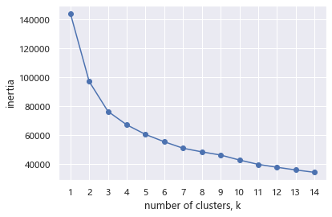

```python
plt.plot(ks, inertias, '-o')
plt.xlabel('number of clusters, k')
plt.ylabel('inertia')
plt.xticks(ks)
plt.savefig('./image/手肘法.png')
plt.show()
```

可以看到k值在等于4的时候趋近于平缓，所以我们取4

```python
model = KMeans(n_clusters=4)
model.fit(scaled_numeric_features)
```

```
KMeans(n_clusters=4)
```

```python
ptarget=model.predict(data2)
```

```python
data2['ptarget'] = ptarget
```

```python
data2.groupby('ptarget').count()
```

| ptarget | brand | notRepairedDamage | kilometer | price | yearsOld | vehicleType |
| --- | --- | --- | --- | --- | --- | --- |
| 0 | 1824 | 1824 | 1824 | 1824 | 1824 | 1824 |
| 2 | 313338 | 313338 | 313338 | 313338 | 313338 | 313338 |
| 3 | 26 | 26 | 26 | 26 | 26 | 26 |

```python
# 查看一下数值型特征的均值情况
kmeans_numeric_features = data2.groupby('ptarget')[['kilometer','price','yearsOld']].mean()
kmeans_numeric_features
```

| ptarget | kilometer | price | yearsOld |
| --- | --- | --- | --- |
| 0 | 15932.017544 | 14858.071272 | 9.990132 |
| 2 | 132975.652490 | 3742.108988 | 16.990991 |
| 3 | 5000.000000 | 25166.615385 | 5.192308 |

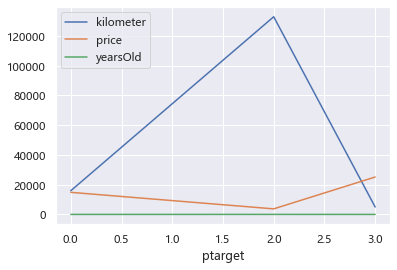

```python
kmeans_numeric_features.plot()
plt.savefig('./image/kmeans_numeric_features.png')
```

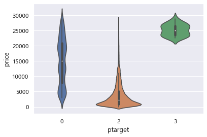

```python
#画小提琴图
sns.violinplot( x=data2["ptarget"], y=data2['price'] )
plt.savefig('./image/kmeans_ptarget_price.png')
```

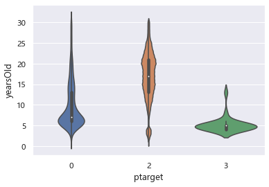

```python
sns.violinplot( x=data2["ptarget"], y=data2['yearsOld'] )
plt.savefig('./image/kmeans_ptarget_yearsOld.png')
```

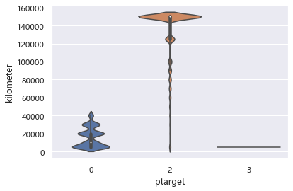

```python
sns.violinplot( x=data2["ptarget"], y=data2['kilometer'] )
plt.savefig('./image/kmeans_ptarget_kilometer.png')
```

从聚类分析的结果来看，聚类结果聚成了三类

1、第一种类型：该种类型的二手车车龄较长，平均车龄在十年左右，里程数较短，价位跨度较大，均价1.5万，款式较老

2、第二种类型：该种类型的二手车车龄较长，平均在十六年左右，里程数较长，价格便宜，款式较老。均价3700左右，也是二手车市场中最大占比的部分。

2、第三种类型：该种类型的二手车车龄较短，里程数较短，价格较高。